# PRÁCTICA PUNTUABLE EN R (BIOESTADÍSTICA/(WDBC))

Leonardo Madsen

6/1/2021

```
Cargamos librerías
```

```r
library(dplyr)
library(ggplot2)
library(DescTools)
library(lmtest)
WDBC <- read.table(file.path("./WDBC.dat"), header=TRUE, sep = "\t")
```

```
Eliminamos las columnas "id", "..._se" y "..._worst"
```

```r
WDBC <- WDBC[, -grep("id|_se|_worst", colnames(WDBC))]
```

```r
colnames(WDBC) <- gsub('_mean', '', colnames(WDBC), fixed=TRUE)
```

```r
WDBC$diagnosis <- as.factor(recode(WDBC$diagnosis, B = "Benigno", M = "Maligno"))
```

```
Sumario de los datos que utilizaremos
```

```r
summary(WDBC)
```

```
##    diagnosis        age            radius          texture
##  Benigno:357   Min.   :30.00   Min.   : 6.981   Min.   : 9.71
##  Maligno:212   1st Qu.:44.00   1st Qu.:11.700   1st Qu.:16.17
##                Median :58.00   Median :13.370   Median :18.84
##                Mean   :56.29   Mean   :14.127   Mean   :19.29
##                3rd Qu.:69.00   3rd Qu.:15.780   3rd Qu.:21.80
##                Max.   :80.00   Max.   :28.110   Max.   :39.28
##    perimeter           area          smoothness       compactness
##  Min.   : 43.79   Min.   : 143.5   Min.   :0.05263   Min.   :0.01938
##  1st Qu.: 75.17   1st Qu.: 420.3   1st Qu.:0.08637   1st Qu.:0.06492
##  Median : 86.24   Median : 551.1   Median :0.09587   Median :0.09263
##  Mean   : 91.97   Mean   : 654.9   Mean   :0.09636   Mean   :0.10434
##  3rd Qu.:104.10   3rd Qu.: 782.7   3rd Qu.:0.10530   3rd Qu.:0.13040
##  Max.   :188.50   Max.   :2501.0   Max.   :0.16340   Max.   :0.34540
##    concavity       concave.points       symmetry      fractal_dimension
##  Min.   :0.00000   Min.   :0.00000   Min.   :0.1060   Min.   :0.04996
##  1st Qu.:0.02956   1st Qu.:0.02031   1st Qu.:0.1619   1st Qu.:0.05770
##  Median :0.06154   Median :0.03350   Median :0.1792   Median :0.06154
##  Mean   :0.08880   Mean   :0.04892   Mean   :0.1812   Mean   :0.06280
##  3rd Qu.:0.13070   3rd Qu.:0.07400   3rd Qu.:0.1957   3rd Qu.:0.06612
##  Max.   :0.42680   Max.   :0.20120   Max.   :0.3040   Max.   :0.09744
```

```
Recuento de diagnosis
```

```r
count.diag <- count(WDBC, diagnosis)
count.diag
```

| diagnosis | n |
| --- | --- |
| Benigno | 357 |
| Maligno | 212 |

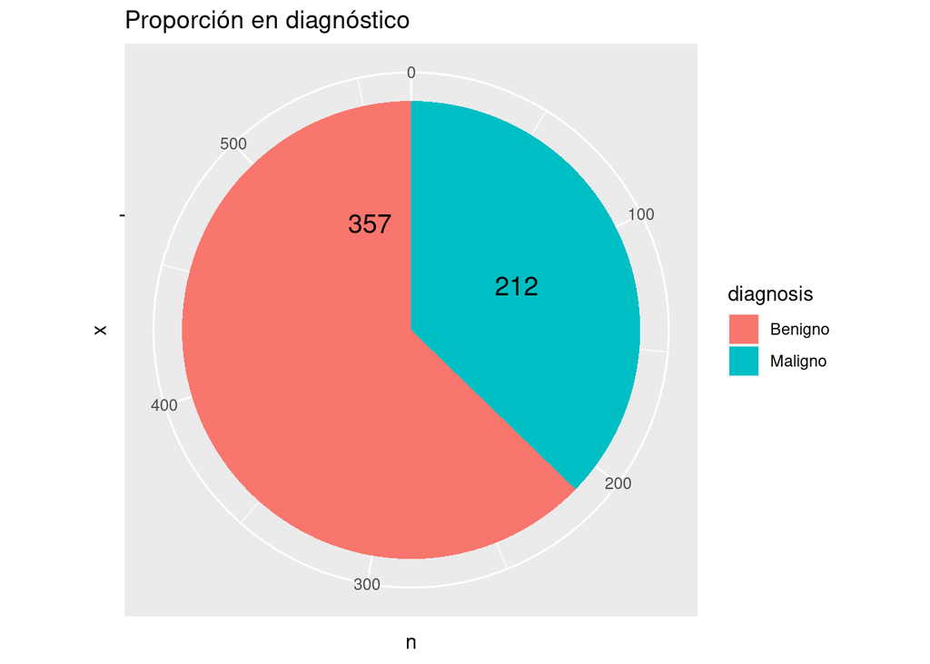

```r
pie<- ggplot(count.diag, aes(x="", y=n, fill=diagnosis)) +
  geom_bar(width = 1, stat = "identity") +
  coord_polar("y", start=0) +
  geom_text(aes(y = n/2 + c(cumsum(n)[-length(n)], 0),
            label = n), size=5) +
  ggtitle("Proporción en diagnóstico")
pie
```

# 1. Seleccionar aleatoriamente una muestra sin reemplazamiento de 50 individuos de cada diagnóstico.

```r
set.seed(1832)
```

```
Selección aleatoria
```

```r
df <- WDBC %>%
  group_by(diagnosis) %>%
  slice_sample(n = 50, replace = FALSE)
df
```

| diagnosis | age | radius | texture | perimeter | area | smoothness | compactness | concavity | concave.points | symmetry | fractal_dimension |
| --- | --- | --- | --- | --- | --- | --- | --- | --- | --- | --- | --- |
| Benigno | 59 | 15.100 | 16.39 | 99.58 | 674.5 | 0.11500 | 0.18070 | 0.113800 | 0.085340 | 0.2001 | 0.06467 |
| Benigno | 36 | 9.333 | 21.94 | 59.01 | 264.0 | 0.09240 | 0.05605 | 0.039960 | 0.012820 | 0.1692 | 0.06576 |
| Benigno | 61 | 13.850 | 19.60 | 88.68 | 592.6 | 0.08684 | 0.06330 | 0.013420 | 0.022930 | 0.1555 | 0.05673 |
| Benigno | 54 | 13.850 | 15.18 | 88.99 | 587.4 | 0.09516 | 0.07688 | 0.044790 | 0.037110 | 0.2110 | 0.05853 |
| Benigno | 51 | 12.270 | 17.92 | 78.41 | 466.1 | 0.08685 | 0.06526 | 0.032110 | 0.026530 | 0.1966 | 0.05597 |
| Benigno | 49 | 13.050 | 18.59 | 85.09 | 512.0 | 0.10820 | 0.13040 | 0.096030 | 0.056030 | 0.2035 | 0.06501 |
| Benigno | 55 | 10.490 | 19.29 | 67.41 | 336.1 | 0.09989 | 0.08578 | 0.029950 | 0.012010 | 0.2217 | 0.06481 |
| Benigno | 78 | 14.740 | 25.42 | 94.70 | 668.6 | 0.08275 | 0.07214 | 0.041050 | 0.030270 | 0.1840 | 0.05680 |
| Benigno | 79 | 12.750 | 16.70 | 82.51 | 493.8 | 0.11250 | 0.11170 | 0.038800 | 0.029950 | 0.2120 | 0.06623 |
| Benigno | 56 | 12.180 | 17.84 | 77.79 | 451.1 | 0.10450 | 0.07057 | 0.024900 | 0.029410 | 0.1900 | 0.06635 |

[output cut: 90 more lines]

```
Comprobamos resultado de la selección aleatoria
```

```r
df %>% count(diagnosis)
```

| diagnosis | n |
| --- | --- |
| Benigno | 50 |
| Maligno | 50 |

```r
quant.03area = quantile(df$area,0.333)
print(quant.03area)
```

```
##    33.3%
## 537.6591
```

```r
quant.06area = quantile(df$area,0.666)
print(quant.06area)
```

```
##    66.6%
## 731.9446
```

```
Categorizamos la variable "area" en tres categorías cada una de un tercio de la cantidad de los datos
```

```r
df[,"area.categorica"] = cut(df$area, breaks = c(min(df$area), quant.03area, quant.06area, max(df$area)),
    labels = c("Pequeña", "Media", "Grande"),
    include.lowest = TRUE)

df$area.categorica <- as.factor(df$area.categorica)

table(df$area.categorica)
```

```
##
## Pequeña   Media  Grande
##      33      33      34
```

```
Categorizamos la variable "texture" en dos categorías divididas según la media
```

```r
df[,"textura.categorica"] = cut(df$texture,
                     breaks = c(min(df$texture), mean(df$texture), max(df$texture)),
                     labels = c("Claro", "Oscuro"),
                     include.lowest = TRUE)

df$textura.categorica <- as.factor(df$textura.categorica)

table(df$textura.categorica)
```

```
##
##  Claro Oscuro
##     49     51
```

# Análisis inferencial.

## En todos los apartados que siguen especificar con detalle las hipótesis de los test, los cálculos hechos y las conclusiones. Considerar una de las variables continuas del conjunto de datos en la que sea posible asumir normalidad. Asumiendo normalidad:

## a. ¿Entre qué valores se mueve la media de la distribución con una confianza del 95%? Suponer varianza desconocida. Interpretar los resultados.

```
Shapiro
```

```r
shapiro.test(df$texture)
```

```
##
##  Shapiro-Wilk normality test
##
## data:  df$texture
## W = 0.99016, p-value = 0.6773
```

```
Nuestro p-value = 0.6773 es mayor al nivel de confianza fijado (0.05) por lo cual no hay evidencias para rechazar la hipótesis nula (H0: la muestra proviene de una distribución normal). Por lo tanto podemos asegurar al 95% que los datos de esta variable se distribuyen según una Normal
```

```r
IC=t.test(df$texture, conf.level = 0.95)
IC$conf.int
```

```
## [1] 18.63809 20.15371
## attr(,"conf.level")
## [1] 0.95
```

```
La media de la distribución de la variable "texture" se mueve entre los valores 18.63809 y 20.15371 con una confianza del 95%
```

```r
shapiro.test(df$perimeter)
```

```
##
##  Shapiro-Wilk normality test
##
## data:  df$perimeter
## W = 0.96958, p-value = 0.02054
```

[output not shown]

## b. Hacer un contraste sobre la media de nivel 0.1 tomando como hipótesis nula el extremo superior del intervalo bilateral del apartado a. Dar el p‐valor e interpretar el resultado.

```r
limite_sup= IC$conf.int[2]
t.test(df$texture, alternative='two.sided',
       conf.level=0.9, mu=limite_sup)
```

```
##
##  One Sample t-test
##
## data:  df$texture
## t = -1.9842, df = 99, p-value = 0.05
## alternative hypothesis: true mean is not equal to 20.15371
## 90 percent confidence interval:
##  18.76177 20.03003
## sample estimates:
## mean of x
##   19.3959
```

```
H0: mu=20.15371 y dado que el p-value = 0.05 es menor al nuestro nivel de confianza (0.1) sí hay evidencias para rechazar esta hipoteisis y declarar que la media de la variable es distinta de 20.15371
```

## Considerar esa misma variable cuantitativa y una variable cualitativa con dos niveles. Suponiendo normalidad:

## c.Hacer un contraste de igualdad de varianzas a nivel 0.05. Dar el p‐valor e interpretar el resultado.

```
HOMOCEDASTICIDAD Es la homogeneidad de varianza de la variable dependiente entre los grupos.
```

```r
bartlett.test(df$texture~df$area.categorica)
```

```
##
##  Bartlett test of homogeneity of variances
##
## data:  df$texture by df$area.categorica
## Bartlett's K-squared = 1.3903, df = 2, p-value = 0.499
```

```
Interpretación:
Con un p-value = 0.499, mayor de 0.05, no podemos rechazar la hipótesis nula. Por lo tanto suponemos homogeneidad de varianzas de las variables "texture" y "area.categorica".
```

```r
bartlett.test(df$texture~df$diagnosis)
```

```
##
##  Bartlett test of homogeneity of variances
##
## data:  df$texture by df$diagnosis
## Bartlett's K-squared = 0.11539, df = 1, p-value = 0.7341
```

```
Interpretación:
Con un p-value = 0.7341, mayor de 0.05, no podemos rechazar la hipótesis nula. Por lo tanto suponemos homogeneidad de varianzas de las variables "texture" y "diagnosis".
```

## d. Hacer un contraste de comparación de medias con varianzas desconocidas, dar el p‐valor e interpretar el resultado

```r
t.test(df$texture~df$diagnosis)
```

```
##
##  Welch Two Sample t-test
##
## data:  df$texture by df$diagnosis
## t = -5.1513, df = 97.768, p-value = 1.344e-06
## alternative hypothesis: true difference in means between group Benigno and group Maligno is not equal to 0
## 95 percent confidence interval:
##  -4.859731 -2.156669
## sample estimates:
## mean in group Benigno mean in group Maligno
##               17.6418               21.1500
```

[output not shown]

## f. Hacer un contraste chi‐cuadrado. Dar el p‐valor e interpretar el resultado.

```r
table(df$diagnosis,df$area.categorica)
```

```
##
##           Pequeña Media Grande
##   Benigno      31    18      1
##   Maligno       2    15     33
```

```
Comprobamos las siguientes hipótesis
H0: No existe relación entre diagnosis y textura.categorica
H1: Si existe relación entre diagnosis y textura.categorica
```

```r
chisq.test(table(df$diagnosis,df$textura.categorica))
```

```
##
##  Pearson's Chi-squared test with Yates' continuity correction
##
## data:  table(df$diagnosis, df$textura.categorica)
## X-squared = 19.368, df = 1, p-value = 1.078e-05
```

```
Puesto que p-value = 1.078e-05 es menor a 0.05, no hay evidencias para aceptar H0, por lo que concluímos H1:sí hay relación entre la "diagnosis" y la "textura.categorica"

Comprobamos las siguientes hipótesis
H_0: No existe relación entre diagnosis y area.categorica
H_1: Si existe relación entre diagnosis y area.categorica
```

```r
chisq.test(table(df$diagnosis,df$area.categorica))
```

```
##
##  Pearson's Chi-squared test
##
## data:  table(df$diagnosis, df$area.categorica)
## X-squared = 55.875, df = 2, p-value = 7.36e-13
```

```
Puesto que p-value = 7.36e-13 es menor a 0.05, no hay evidencias para aceptar H0, por lo que concluímos H1:sí hay relación entre la "diagnosis" y la "area.categorica"
```

## g. Calcular una medida de asociación junto con un intervalo de confianza del 95%. Interpretar los resultados.

```r
diag_tex_tb <- table(df$textura.categorica,df$diagnosis)
diag_tex_tb
```

```
##
##          Benigno Maligno
##   Claro       36      13
##   Oscuro      14      37
```

```
El odds ratio (OR) expresa si la probabilidad de ocurrencia del evento Benigno/Maligno difiere o no en los grupos Claro/Oscuro
```

```r
res <- OddsRatio(diag_tex_tb, conf.level=0.95)
res
```

```
## odds ratio     lwr.ci     upr.ci
##   7.318681   3.025323  17.704917
```

[output not shown]

# 4. ANOVA y Regresión:

## a. Categorizar, en tres grupos, una de las variables cuantitativas medidas en las imágenes y llevar a cabo un ANOVA.

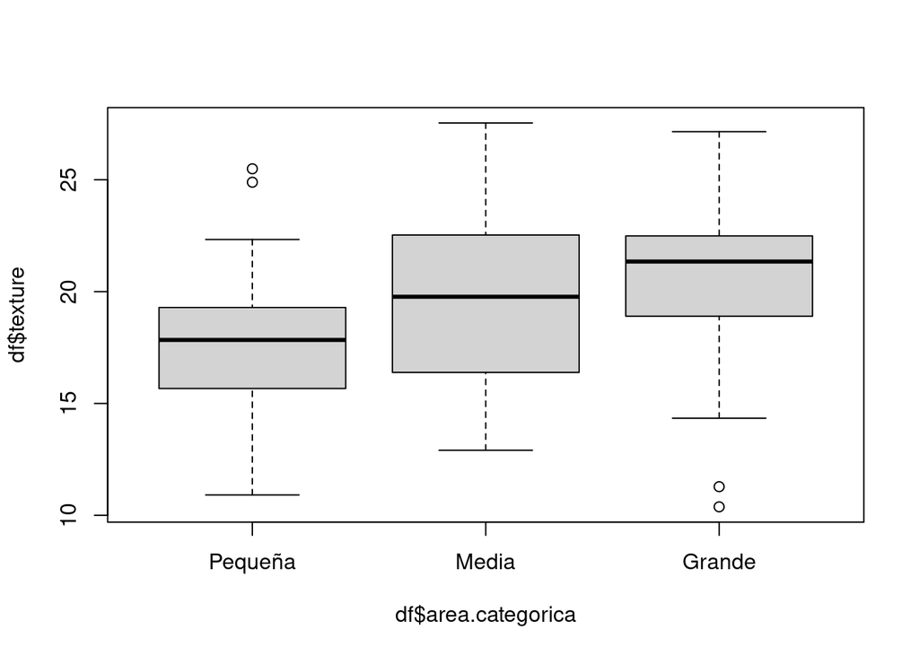

[output not shown]

```r
boxplot(df$texture ~ df$area.categorica)
```

```r
aov1 <-aov(df$texture ~ df$area.categorica)
summary(aov1)
```

```
##                    Df Sum Sq Mean Sq F value  Pr(>F)
## df$area.categorica  2  154.5   77.27   5.812 0.00413 **
## Residuals          97 1289.5   13.29
## ---
## Signif. codes:  0 '***' 0.001 '**' 0.01 '*' 0.05 '.' 0.1 ' ' 1
```

```
El nivel de significancia Pr(>F)=0.00413 es menor que "0.05" por lo que hay evidencias para rechazar "H0: las medias son iguales", lo que indica que las medias son diferentes.
Aun no sabemos cuál media es diferente de cuál. aunque podemos intuir que son las medias de "area pequeña" y "area grande" las que son diferentes entre si.

Realizamos la prueba de Tukey
```

```r
TukeyHSD(aov1)
```

```
##   Tukey multiple comparisons of means
##     95% family-wise confidence level
##
## Fit: aov(formula = df$texture ~ df$area.categorica)
##
## $`df$area.categorica`
##                     diff       lwr      upr     p adj
## Media-Pequeña  2.0690909 -0.067380 4.205562 0.0598061
## Grande-Pequeña 2.9681194  0.847416 5.088823 0.0034765
## Grande-Media   0.8990285 -1.221675 3.019732 0.5729622
```

```
Puesto que "Grande-Pequeña" p adj = 0.0034 es menor a 0.05 podemos corroborar que las medias de Grande y Pequeña son significativamente distintas
```

## b. Efectuar un análisis de regresión lineal simple de dos de las variables continuas del conjunto de datos.

### I. Dar la ecuación del modelo. Interpretar el modelo.

```r
model0 <- lm(formula =  area ~ texture, data = df)
summary(model0)
```

```
##
## Call:
## lm(formula = area ~ texture, data = df)
##
## Residuals:
##     Min      1Q  Median      3Q     Max
## -688.64 -227.33  -81.82  181.66 1024.77
##
## Coefficients:
##             Estimate Std. Error t value Pr(>|t|)
## (Intercept)  242.972    173.417   1.401   0.1643
## texture       24.498      8.774   2.792   0.0063 **
## ---
## Signif. codes:  0 '***' 0.001 '**' 0.01 '*' 0.05 '.' 0.1 ' ' 1
##
## Residual standard error: 333.4 on 98 degrees of freedom
## Multiple R-squared:  0.07369,    Adjusted R-squared:  0.06424
## F-statistic: 7.796 on 1 and 98 DF,  p-value: 0.006296
```

```
Interpretación:

El área está linealmente relacionada con la textura según la siguiente fórmula:
```

$area = 242.972 + 24.498 * texture$

```
La ordenada en el origen (Intercept) es 242.972 por lo que valores de textura igual a 0 estimarán valores de área igual a 242.972.
La pendiente es 24.498 por lo que cada aumento medio en una unidad de textura producirá un aumento de 24.498 de area.
El estadístico F ( 7.796) contrasta si el modelo tiene significativa capacidad predictiva.
En el contraste la hipótesis nula es F = 1, con un p-valor menor de 0.05 (p-value: 0.006296) se rechaza la hipótesis nula. Por lo tanto concluimos que el modelo tiene una capacidad predictiva significativa.
```

### II. Estudiar la significación del modelo y la bondad de ajuste.

```
Se muestra un valor del estadístico de contraste F de  7.796  con un  p_valor = 0.006296. Deduciendo que a un nivel de significación del  5%, (p_valor < 0.05), rechazamos la hipótesis nula, y podemos concluir que el modelo lineal es adecuado para nuestro conjunto de datos.
Respecto a la bondad del ajuste, el coeficiente de determinación  R² tiene un valor de 0.07369, indica que el 7.36% de toda la variabilidad que tiene el fenómeno relativo al "area" puede ser explicado por la "texture".
```

### III. Hacer un análisis residual, incluir los gráficos apropiados y estudiar la adecuación del modelo.

```
Realizaremos el diagnóstico de los residuos. Normalidad de los residuos, homogeneidad de varianzas e incorrelación de los residuos
```

```r
shapiro.test(model0$residuals)
```

```
##
##  Shapiro-Wilk normality test
##
## data:  model0$residuals
## W = 0.93329, p-value = 7.683e-05
```

```
  El Shapiro-Wilk normality test nos indica que no hay evidencias para aceptar la hipótesis nula (H0:los residuos se distribuye según una Normal). Por lo cual No se cumple una de las hipótesis fundamentales del modelo de regresión, el de normalidad de residuos
```

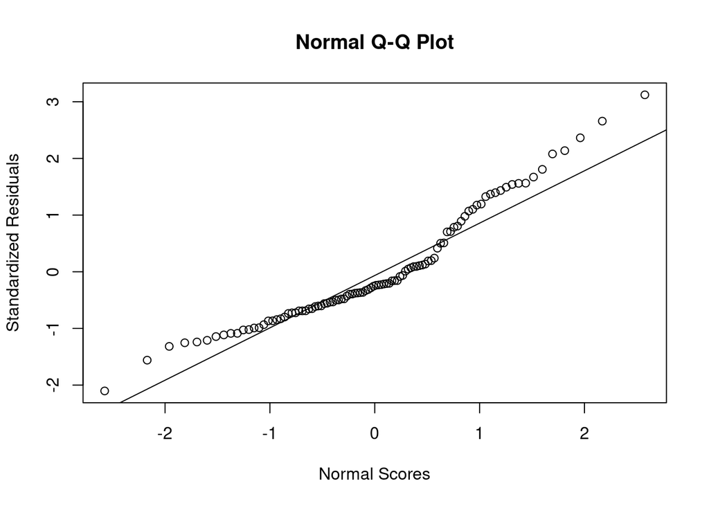

```r
model0.stdres <- rstandard(model0)
qqnorm(model0.stdres,  ylab="Standardized Residuals", xlab="Normal Scores")
qqline(model0.stdres)
```

```r
bptest(model0)
```

```
##
##  studentized Breusch-Pagan test
##
## data:  model0
## BP = 2.6195, df = 1, p-value = 0.1056
```

```
Interpretación:
Con un p-value =  0.1056, mayor de 0.05, no podemos rechazar la hipótesis nula. Por lo tanto suponemos homogeneidad de varianzas en los residuos.
```

```r
dwtest(model0)
```

```
##
##  Durbin-Watson test
##
## data:  model0
## DW = 1.2234, p-value = 3.698e-05
## alternative hypothesis: true autocorrelation is greater than 0
```

```
Interpretación:
Con un p-value = 3.698e-05, menor de 0.05, hay indicios para rechazar la hipótesis nula. Por lo tanto no suponemos incorrelación para los residuos estudentizados del modelo ajustado.
```

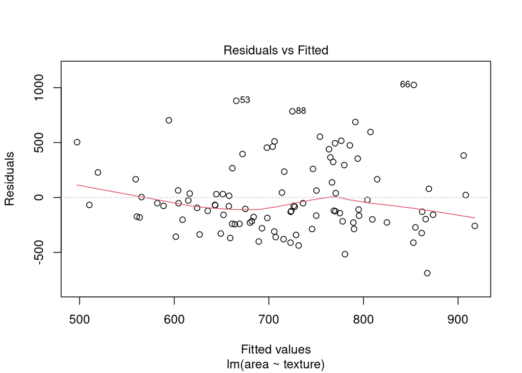

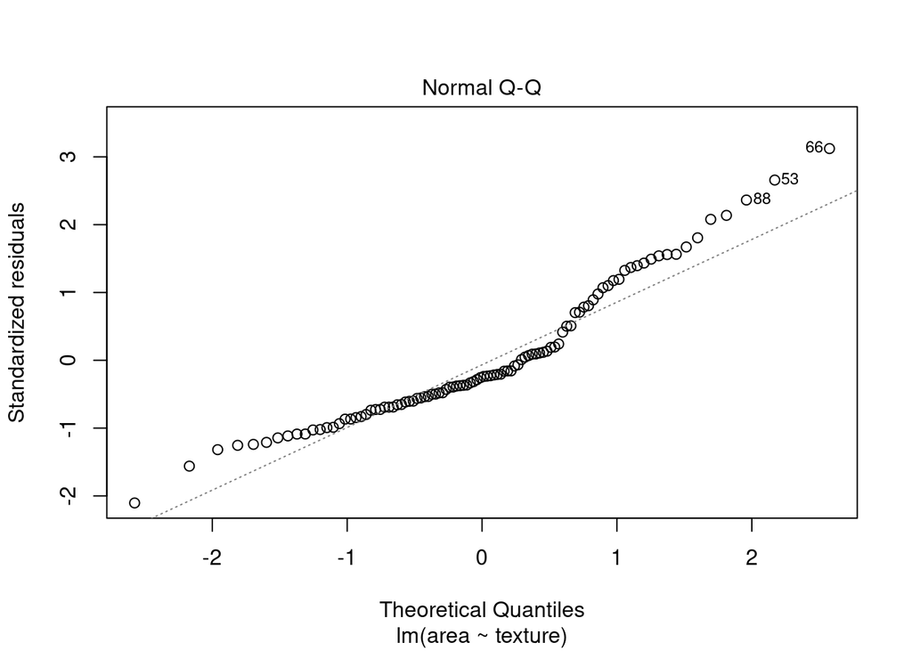

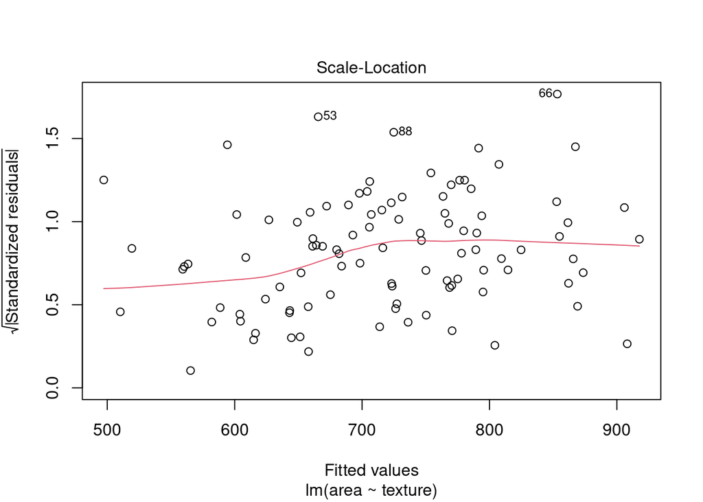

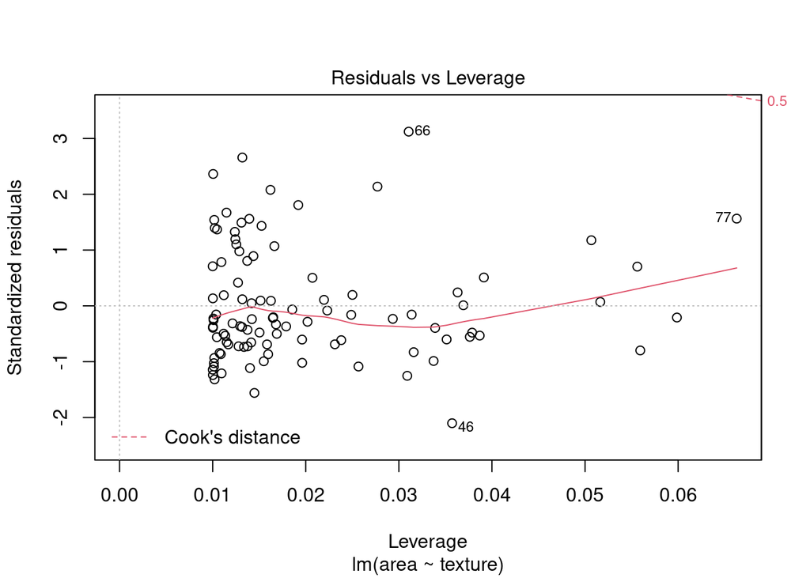

```r
plot(model0)
```

### IV.Si el modelo no es apropiado tratar de encontrar transformaciones que corrijan el modelo obteniendo un modelo aceptable.

```r
model1 <- lm(formula =  area ~ I(texture^2), data = df)
model2 <- lm(formula =  area ~ log(texture), data = df)
model3 <- lm(formula =  area ~ I(texture^(-1)), data = df)
model_cuadratico <- lm(formula =  area ~ poly(texture, 1), data = df)
model_cuadratico2 <- lm(formula =  area ~ poly(texture, 2), data = df)
```

```r
 anova(model0, model1)
```

|  | Res.Df | RSS | Df | Sum of Sq | F | Pr(>F) |
| --- | --- | --- | --- | --- | --- | --- |
| 1 | 98 | 10894349 | NA | NA | NA | NA |
| 2 | 98 | 10890032 | 0 | 4317.345 | NA | NA |

```r
 anova(model0, model3)
```

|  | Res.Df | RSS | Df | Sum of Sq | F | Pr(>F) |
| --- | --- | --- | --- | --- | --- | --- |
| 1 | 98 | 10894349 | NA | NA | NA | NA |
| 2 | 98 | 11072194 | 0 | -177844.6 | NA | NA |

```r
anova(model0, model_cuadratico)
```

|  | Res.Df | RSS | Df | Sum of Sq | F | Pr(>F) |
| --- | --- | --- | --- | --- | --- | --- |
| 1 | 98 | 10894349 | NA | NA | NA | NA |
| 2 | 98 | 10894349 | 0 | 1.862645e-09 | NA | NA |

```r
anova(model0, model_cuadratico2)
```

|  | Res.Df | RSS | Df | Sum of Sq | F | Pr(>F) |
| --- | --- | --- | --- | --- | --- | --- |
| 1 | 98 | 10894349 | NA | NA | NA | NA |
| 2 | 97 | 10888586 | 1 | 5763.143 | 0.05134044 | 0.8212238 |

```
Tratando de encontrar transformaciones que mejore el modelo no hemos obteniendo un modelo aceptable.

Comparamos los modelos siguiendo el criterio de información de Akaike
```

```r
cbind(model0=AIC(model0), model1=AIC(model1), model2=AIC(model2), model3=AIC(model3), model_cuadratico=AIC(model_cuadratico), model_cuadratico2=AIC(model_cuadratico2))
```

```
##        model0   model1   model2   model3 model_cuadratico model_cuadratico2
## [1,] 1449.646 1449.607 1450.205 1451.265         1449.646          1451.593
```

[output not shown]

## c. A partir de la variable diagnosis , ajustar un modelo que nos permita predecir la probabilidad de tener un tumor maligno. El modelo debe incluir al menos 5 variables independientes. Identifica e interpreta factores de riesgo/protección.

```
Convertimos la variable "diagnosis" a  numérico (Benigno = 0, Maligno = 1)
```

```r
df$diagnosis.fac <- c(rep(0,50),rep(1,50))
```

```r
model.m <- lm(formula =  diagnosis.fac ~ I(perimeter^2) + radius + texture  + concavity + area, data = df)
summary(model.m)
```

```
##
## Call:
## lm(formula = diagnosis.fac ~ I(perimeter^2) + radius + texture +
##     concavity + area, data = df)
##
## Residuals:
##      Min       1Q   Median       3Q      Max
## -0.60550 -0.14438 -0.00133  0.17162  0.68138
##
## Coefficients:
##                  Estimate Std. Error t value Pr(>|t|)
## (Intercept)    -1.811e+00  4.575e-01  -3.958 0.000147 ***
## I(perimeter^2) -3.130e-04  6.753e-05  -4.635 1.15e-05 ***
## radius          1.223e-01  5.633e-02   2.170 0.032500 *
## texture         3.378e-02  6.958e-03   4.855 4.78e-06 ***
## concavity       4.679e+00  6.148e-01   7.611 2.07e-11 ***
## area            3.436e-03  1.106e-03   3.106 0.002508 **
## ---
## Signif. codes:  0 '***' 0.001 '**' 0.01 '*' 0.05 '.' 0.1 ' ' 1
##
## Residual standard error: 0.253 on 94 degrees of freedom
## Multiple R-squared:  0.7593, Adjusted R-squared:  0.7465
## F-statistic: 59.32 on 5 and 94 DF,  p-value: < 2.2e-16
```

```
Interpretación:
diagnosis está linealmente relacionada con perimeter, radius, texture, concavity y area según la siguiente fórmula:
```

$diagnosis = -1.811 -3.130e^{-4} * perimeter^2 + 1.223e^{-1} * radius + 3.378e^{-2} * texture + 4.679 * concavity + 3.436e^{-3} * area$

```
El estadístico F (59.32) contrasta si el modelo tiene significativa capacidad predictiva.
En el contraste la hipótesis nula es F = 1, con un p-valor menor de 0.05 (p-value: < 2.2e-16) se rechaza la hipótesis nula. Por lo tanto concluimos que el modelo tiene una capacidad predictiva significativa.
El R2 ajustado = 0.7465 , lo que significa que “perimeter, radius, texture, concavity y area pueden predecir el 74% de la varianza en la estimación de diagnosis.
Los coeficiente de las variables radius, texture, concavity y area son positivos por tanto  corresponden a factores de riesgo.
Por el contrario, el coeficiente de perimeter^2 es negativo por lo que se trata de un factor de protección
```